# carnet-de-guerre-analyse-de-sentiment

[figure not shown]

*Photographie de plateau - une infirmière et un blessé - Médiathèque de l'architecture et du patrimoine*

Ce carnet de guerre est celui d'Adrienne D'Urville ([source](https://fr.wikisource.org/wiki/Carnets_de_guerre_d%E2%80%99Adrienne_Durville/Texte_entier)), infirmière mobilisé sur le front en Alsace dès 1914. Elle y décrit quotidiennement pendant presque cinq ans son travail rythmé par les entrées et sorties des soldats de l'hopital militaire et ponctué par de rares nouvelles du front.

*Objectif: mesurer la joie et la tristesse de l'autrice du carnet, au fil des jours. Puis tenter de comprendre quels sont les évènements marquant son expérience de la Grande guerre.*

```python
import numpy as np
import pandas as pd
from datetime import datetime
import plotly.express as px
import matplotlib.pyplot as plt
from IPython.display import Image
from transformers import pipeline

import warnings
warnings.filterwarnings('ignore')
```

# 1. Charger le livre en mémoire

```python
livre = []
with open('/kaggle/input/livre-durville/Carnets_de_guerre_dAdrienne_Durville_Texte_entier.txt','r') as f:
    for l in f:
        if len(l.strip())>0:
            livre.append(l.strip())
```

On construit un dataframe dans lequel chaque ligne correspond à un paragraphe du livre, ansi que sa date d'écriture.

```python
JOURS = ['lundi','mardi','mercredi','jeudi','vendredi','samedi','dimanche']
MOIS = ['janvier','février','mars','avril','mai','juin','juillet','août','septembre','octobre','novembre','décembre']

curr_annee = None
curr_mois = 1
curr_jour = 1

jour_col = []
mois_col = []
annee_col = []
timestamp_col = []
date_str_col = []
texte_col = []

corps_livre = False

for l in livre:
    l_orig = l
    l = l.lower().replace(',','').replace('.','')

    # Si la ligne n'est pas vide
    if len(l)==0:
        break

    # Fin du livre
    if l=='à propos de cette édition électronique':
        break

    ligne_date = False
    for j in JOURS:
        if l.startswith(j):
            ligne_date = True
            corps_livre = True
            break

    # Ligne contenant une date
    if ligne_date:
        line_split = l.split(' ')
        if len(line_split)>10:
            # La ligne contient plus que la date
            line_split = line_split[:3]
        if line_split[-1].isnumeric():
            if len(line_split[-1])==4:
                # La ligne contient une année
                j,m,a = line_split[-3:]
                curr_jour = j
                curr_mois = MOIS.index(m)+1
                curr_annee = int(a)
            elif len(line_split[-1])==2:
                # La ligne contient juste le jour sans le mois ni l'année
                curr_jour = line_split[-1]
        else:
            # La ligne contient le jour et le mois
            j,m = line_split[-2:]
            curr_jour = j
            curr_mois = MOIS.index(m)+1

        # Cas particulier pour les jours
        if curr_jour=='1er':
            curr_jour = 1
        elif curr_jour=='19-21':
            curr_jour = 20
        elif curr_jour=='215':
            curr_jour = 21
        else:
            curr_jour = int(curr_jour)

    # Ligne contenant du texte
    elif corps_livre:
        phrase = l_orig.strip()
        if len(phrase)>5:
            jour_col.append(curr_jour)
            mois_col.append(curr_mois)
            annee_col.append(curr_annee)

            dt = datetime(curr_annee,curr_mois,curr_jour)
            timestamp_col.append(dt.timestamp())
            date_str_col.append(dt.strftime('%d/%m/%Y'))
            texte_col.append(phrase)

# Construction d'une DataFrame
livre_df = pd.DataFrame({'jour':jour_col,'mois':mois_col,'annee':annee_col,
              'timestamp':timestamp_col,'date_str':date_str_col,'texte':texte_col})

livre_df.head()
```

|  | jour | mois | annee | timestamp | date_str | texte |
| --- | --- | --- | --- | --- | --- | --- |
| 0 | 1 | 8 | 1914 | -1.748909e+09 | 01/08/1914 | À 5 heures, affichage à Valmondois de la mobil... |
| 1 | 1 | 8 | 1914 | -1.748909e+09 | 01/08/1914 | Dans le train, entendu conversation d’ouvriers... |
| 2 | 2 | 8 | 1914 | -1.748822e+09 | 02/08/1914 | 7 h Messe et Communion. Dieu protège la France... |
| 3 | 2 | 8 | 1914 | -1.748822e+09 | 02/08/1914 | 10 h. Rue François I pour savoir à quelle heur... |
| 4 | 2 | 8 | 1914 | -1.748822e+09 | 02/08/1914 | 11 h. Je rentre rue de Condé ; valise, je me m... |

# 2. Première analyse du carnet

On regroupe groupe les paragraphes du livre par jour (une ligne du dataframe par jour).

```python
def concat(lines):
    return ' '.join(lines)

livre_df = livre_df.groupby(['jour','mois','annee','timestamp','date_str'],as_index=False).agg({'texte':concat})
livre_df['datetime'] = pd.to_datetime(livre_df['date_str'],format='%d/%m/%Y')
livre_df.sort_values(by=['timestamp'],inplace=True)
```

En visualisant le nombre de jours retranscris par mois, on observe que l'autrice du carnet a écris avec une très grande régularité pendant 5 ans. Cependant nous pouvons observer deux petites périodes "creuses", début 1917 et à partir d'Avril 1919.

```python
fig = px.histogram(livre_df, x='datetime', y='texte', histfunc='count',
                   title='Nombre de jours retranscris par mois',color_discrete_sequence=['IndianRed '])
fig.update_traces(xbins_size='M1')
fig.update_xaxes(ticklabelmode='period', dtick='M1')
fig.update_layout(bargap=0.1)
fig.show()
```

[interactive chart not shown]

En explorant les jours correspondant à la période de début 1917, on s'aperçoit qu'elle correspond à un moment de démobilisation du front:

```python
print('Janvier 1917\n-------------')
for idx,row in livre_df[(livre_df.mois==1)&(livre_df.annee==1917)].iterrows():
    print('{}: {} ...'.format(row['date_str'][:100],row['texte'][:100]))

print('\nFévrier 1917\n-------------')
for idx,row in livre_df[(livre_df.mois==2)&(livre_df.annee==1917)].iterrows():
    print('{}: {} ...'.format(row['date_str'][:100],row['texte'][:100]))
```

```
Janvier 1917
-------------
01/01/1917: Le troisième jour de l’an de guerre. Est-ce la victoire que nous amènera cette année ? Visites toute ...
03/01/1917: Messe à Ste Geneviève ; aurons-nous bientôt un poste intéressant ? Visite chez Jeanne ; son mari est ...
04/01/1917: Thé chez Julie avec Hallopeau et sa femme, Haas et Renée, surprise de l’arrivée de Mlle de Laur et d ...
05/01/1917: Visite à Mme de Barrau ; il est question d’envoyer l’h. d E. aux environs de Belfort avec Piéry pour ...
08/01/1917: Rendez-vous chez Julie avec Mme Millet ; potins sur le Lac. Mme de B. a vu Regaud ; il y aura des po ...
10/01/1917: Pantaloni est nommé au Lac, à l’indignation générale ; c’est un vilain tour de Lambert que l’on juge ...
12/01/1917: Visite à Jeanne qui va très bien maintenant, le bébé pousse. ...
15/01/1917: Thé chez Renée avec Julie, Mme de B. et Suchaux à Paris pour deux jours. Il vient demander son chang ...
16/01/1917: Mme de B. a vu Regaud, beaucoup moins aimable. Cela ne va pas du tout entre le ministère et la Socié ...
17/01/1917: Thé chez Renée avec Julie et Blanc. Le Dr Haas est nommé à Paris. Rien de nouveau au point de vue mi ...
18/01/1917: Le docteur Haas est nommé à l’école militaire, c’est une joie. Visite à Mme Legueu qui demande des g ...
30/01/1917: Toujours rien pour nous, Mme de B. et Julie continuent leurs visites au ministère ; aucun hôpital n’ ...

Février 1917
-------------
02/02/1917: Dîner à Lutetia avec le Cl Segonne, nous trois et les Haas. Le colonel nous croit à Paris pour un mo ...
10/02/1917: Toujours rien de nouveau, nous ne partirons que juste pour l’offensive, mais quand ? Vu Miribel, tou ...
19/02/1917: Julie part pour Vannes, notre départ reculant de plus en plus. Nouvelles de Gérardmer, le Lac est co ...
26/02/1917: Thé chez Renée avec le Colonel ; la 66e est toujours près de Belfort et va retourner dans un camp d’ ...
27/02/1917: Retour de Julie ; il y a enfin du nouveau, on nous offre un H O E près de Compiègne avec Mlle d’H. o ...
28/02/1917: La C. R. demande une réponse, en ajoutant Moyen aux offres précédentes, nous sommes de plus en plus  ...
```

Sans surprise, la baisse de régularité en 1919 s'explique facilement par la fin de la guerre:

```python
print('Avril 1919\n-------------')
for idx,row in livre_df[(livre_df.mois==4)&(livre_df.annee==1919)].iterrows():
    print('{}: {} ...'.format(row['date_str'][:100],row['texte'][:100]))

print('\nMai 1919\n-------------')
for idx,row in livre_df[(livre_df.mois==5)&(livre_df.annee==1919)].iterrows():
    print('{}: {} ...'.format(row['date_str'][:100],row['texte'][:100]))

print('\nJuin 1919\n-------------')
for idx,row in livre_df[(livre_df.mois==6)&(livre_df.annee==1919)].iterrows():
    print('{}: {} ...'.format(row['date_str'][:100],row['texte'][:100]))

print('\nJuillet 1919\n-------------')
for idx,row in livre_df[(livre_df.mois==7)&(livre_df.annee==1919)].iterrows():
    print('{}: {} ...'.format(row['date_str'][:100],row['texte'][:100]))
```

```
Avril 1919
-------------
18/04/1919: Arrivée de ma citation et de ma croix de guerre. ...

Mai 1919
-------------
06/05/1919: Goûter chez Julie avec Renée et H. à qui j’avais demandé de me remettre ma croix de guerre. Il l’a f ...
07/05/1919: Remise aux délégués allemands à Versailles, des conditions de paix. ...

Juin 1919
-------------
23/06/1919: Je dîne chez les Haas ; à 7 heures sirènes, canon : un moment d’inquiétude d’abord, puis les explica ...
28/06/1919: Signature à Versailles, dans la galerie des Glaces, pour la revanche de 1870. Cette revanche à laque ...

Juillet 1919
-------------
14/07/1919: D’abord la veillée des morts, devant ce cénotaphe bête, mais devenu grand quand même par ce que nous ...
```

# 3. Analyse de sentiment

L'analyse de sentiment en Français souffre d'un manque de datasets annotés (et donc de modèles entraînés). Les principaux sont extraits de reviews (comme [Amazon](https://huggingface.co/datasets/allocine) ou [Allocine](https://huggingface.co/datasets/amazon_reviews_multi)). Or les modèles qui ont été "fine-tuned" avec ces datasets, ne sont pas vraiment adaptés à notre cas, car "sentiment" recouvre un concept différent dans les deux contexte.

**Exemple:**

Un beau film triste, provoquant la tristesse est un bon film, méritant donc les 5 étoiles Allociné. Or la tristesse dans un carnet de guerre est sans équivoque une émotion négative. Les modèles suivant, entraînés à partir de ces datasets reproduisent bien ce problème:

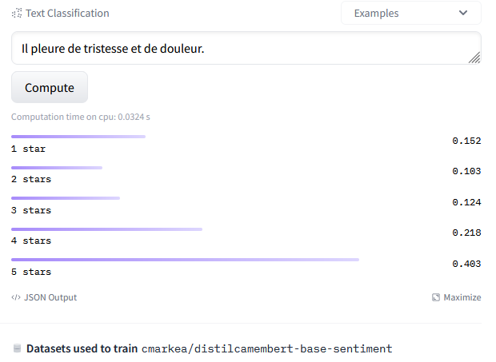

```python
Image('../input/sentiment-sample/cmarkea.png')
```

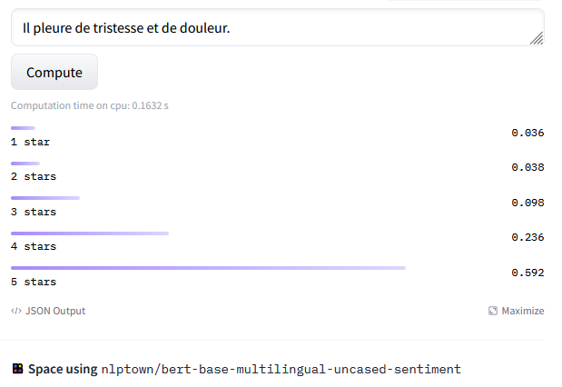

```python
Image('../input/sentiment-sample/nlptown.png')
```

Pour contourner ce problème, nous utilisons à la place un modèle "zero-shot" pour classifier les émotion. Ce type de classifieur ne requiert pas spécialement une surcouche d'apprentissage spécifique, mais se base sur l'énorme base de connaissances linguistique déjà disponible dans un modèle préentraîné comme BERT (Camembert pour la version française). Un tel modèle est capable de calculer une distance (transformé en probabilité) entre un texte et un sujet quelconque (qu'il n'a pas été explicitement entraîné à reconnaître).

```python
checkpoint = 'BaptisteDoyen/camembert-base-xnli'
classifier = pipeline(
    'zero-shot-classification',
    model=checkpoint
)
```

Dans ce cas précis, il nous suffit de classifier chaque texte entre les sujets `joie` et `tristesse`.

```python
candidate_labels = ['joie','tristesse']
result_sentiment = classifier(
    list(livre_df.texte),
    candidate_labels
)
```

Dans la foulée, nous allons tenter de séparer les émotions liées au travail journalier de l'autrice, des celles provoquées par le déroulement militaire de la guerre (même si les deux sont un peu liées).

```python
candidate_labels = ['hôpital','guerre']
result_topic = classifier(
    list(livre_df.texte),
    candidate_labels
)
```

On intègre les résultats à notre dataframe.

```python
def calc_score(res,label):
    sentiment = []
    for r in res:
        sentiment.append(r['scores'][r['labels'].index(label)])
    return sentiment

livre_df['joie'] = calc_score(result_sentiment,'joie')
livre_df['tristesse'] = calc_score(result_sentiment,'tristesse')
livre_df['hopital'] = calc_score(result_topic,'hôpital')
livre_df['guerre'] = calc_score(result_topic,'guerre')
```

```python
livre_df.to_csv('livre_df.csv',index=False)
#livre_df = pd.read_csv('../input/livre-df/livre_df.csv')
livre_df['datetime'] = pd.to_datetime(livre_df['date_str'],format='%d/%m/%Y')
livre_df.sort_values(by=['timestamp'],inplace=True)
```

# 4. Visualisation

Pour les besoins de la visualisation, on ajoute des retours à la ligne au delà de 70 caractères, et on décale le score de `joie` entre `-0.5` et `+0.5`.

```python
MAX_CAR_LIGNE = 70
def a_la_ligne(t):
    toks = t.split(' ')
    texte = ''
    nb_car = 0
    for tok in toks:
        if nb_car+len(tok)>MAX_CAR_LIGNE:
            texte+='<br>'
            nb_car = 0

        texte+=' '+tok
        nb_car+=len(tok)
    return texte

livre_df['texte_'] = livre_df['texte'].apply(a_la_ligne)
livre_df['joie']-=.5
```

```python
fig = px.area(livre_df[livre_df.guerre>.7],
              x='datetime', y='joie', title='Guerre',
              color_discrete_sequence=['MidnightBlue'],line_shape='spline',markers=True,
              hover_data=['datetime','joie','texte_'])

fig.update_xaxes(
    dtick="M1",
    ticklabelmode="period",
    rangeslider_visible=True,
    rangeselector=dict(
        buttons=list([
            dict(count=6, label="6m", step="month", stepmode="backward"),
            dict(count=1, label="1y", step="year", stepmode="backward"),
            dict(step="all")
        ])
    )
)

fig.show()
```

[interactive chart not shown]

Le résultat semble satisfaisant pour repérer d'un coup d'oeil les victoires et les défaites militaires:

```python
dates_even_guerre = ['12/01/1915','15/05/1915','18/07/1915','11/01/1916','22/02/1916','12/02/1916','17/03/1917','01/06/1917','19/08/1917','28/11/1917','20/02/1918','06/04/1918','22/06/1918','19/06/1918']
for idx,row in livre_df[livre_df.date_str.isin(dates_even_guerre)].sort_values('timestamp').iterrows():
    prefix = '\033[92m'
    if row['joie']<0:
        prefix = '\033[91m'
    print('{}{} (Joie:{:.2f}): {} ...'.format(prefix,row['date_str'][:100],row['joie'],row['texte'][:120]))
```

```
12/01/1915 (Joie:-0.47): Les nouvelles d’Alsace sont tristes : Burnhaupt a été perdu par bêtise ; le village a été occupé par une compagnie de te ...
15/05/1915 (Joie:0.22): Les progrès à Arras continuent lentement ; ce ne sera pas une vraie percée, mais un recul des lignes allemandes, en atte ...
18/07/1915 (Joie:0.18): Messe militaire. Une légère attaque du côté de Dannemarie ; les Allemands sont repoussés. ...
11/01/1916 (Joie:-0.47): La situation tourne à l’aigre au Lac ; Mme L. T. a le cafard et le montre à tout le monde. Elle est particulièrement dés ...
12/02/1916 (Joie:-0.48): Toujours le bombardement de B. ; c’est désolant. Visite de Sabardan, il me parle de Péronne avec assez d’ironie. Au mome ...
22/02/1916 (Joie:0.44): Bonne journée pour l’aviation ; un des Taube qui est venu nous survoler est tombé à Fraize, un autre a été démoli à Épin ...
17/03/1917 (Joie:0.39): Le manifeste du tsar est très beau et très digne ; la révolution a l’air faite pour la guerre et contre les boches ; pou ...
01/06/1917 (Joie:-0.42): Notre nuit a été interrompue par trois bombardements d’avions. Les bombes tombent tout près du camp, canonnade, mitraill ...
19/08/1917 (Joie:0.32): La 66e don va au repos après des combats où elle a fait merveille ; le colonel n’ira pas à Athènes où on enverra de préf ...
28/11/1917 (Joie:0.37): C’est la 128e Don qui a fait la dernière attaque de Verdun ; tout a très bien marché avec le minimum de pertes. ...
20/02/1918 (Joie:-0.43): La Russie signe la paix et accepte toutes les conditions boches. C’est la catastrophe prévue depuis longtemps. Et dire q ...
06/04/1918 (Joie:-0.38): Les Portugais se font battre, les boches avancent de nouveau. Notre ordre arrive de la C. R. mais cela n’est pas suffisa ...
19/06/1918 (Joie:0.26): Grande offensive autrichienne en Italie ; les Italiens résistent bien, encadrés par nous. Attaque de Reims par les boche ...
22/06/1918 (Joie:0.44): C’est une vraie victoire que nous avons eue en Italie, et qui aura une très grosse importance pour l’offensive à venir. ...
```

Les évènements liés à l'hôpital sont beaucoup plus nombreux et font preuve d'une grande variabilité en terme de sentiment :

```python
fig = px.area(livre_df[livre_df.hopital>.7],
              x='datetime', y='joie', title='Hopital',
              color_discrete_sequence=['Tomato'],line_shape='spline',markers=True,
              hover_data=['datetime','joie','texte_'])

fig.update_xaxes(
    dtick="M1",
    ticklabelmode="period",
    rangeslider_visible=True,
    rangeselector=dict(
        buttons=list([
            dict(count=6, label="6m", step="month", stepmode="backward"),
            dict(count=1, label="1y", step="year", stepmode="backward"),
            dict(step="all")
        ])
    )
)

fig.show()
```

[interactive chart not shown]

Malgré tout, il semble que la positivité/négativité de ces évènements soit en règle générale bien appréciée par notre modèle :

```python
for idx,row in livre_df[(livre_df.hopital>.7)&(abs(livre_df.joie)>.48)].iterrows():
    prefix = '\033[92m'
    if row['joie']<0:
        prefix = '\033[91m'
    print('{}{} (Joie:{:.2f}): {} ...'.format(prefix,row['date_str'][:100],row['joie'],row['texte'][:120]))
```

```
01/02/1915 (Joie:-0.48): Opération de Desnoyers, c’est atrocement pénible, le pauvre petit pleure ; il est si faible que l’on se demande s’il pou ...
01/05/1916 (Joie:0.49): Messe à 6 heures. Levêque reçoit sa nomination de médecin auxiliaire au 11e bon de chasseurs. Il est dans la joie. Je va ...
17/07/1916 (Joie:-0.48): Départ assez triste, Pouchau et Mme Perrine pleurent ; nous recevons à B. un accueil charmant ; médecin, de Laur, blessé ...
11/09/1916 (Joie:-0.49): Départ de Julie ; le trio perd son « âme », nous sommes toutes tristes. Première communion de ma petite fille que l’on o ...
06/06/1917 (Joie:-0.49): Encore 7 infirmières qui partent. Cela déblaie ; toutes ces femmes inoccupées étaient bien ennuyeuses. Continuation de l ...
24/09/1917 (Joie:0.49): Bonne surprise de la visite de Villechaise et d’H. Quel plaisir ils nous font ; cela nous rappelle G. et tous ses bons s ...
27/10/1917 (Joie:-0.49): Une triste nouvelle, le neveu de Julie est gravement blessé et soigné dans une ambulance voisine de celle d’H.. Elle y p ...
27/06/1918 (Joie:-0.49): Le pauvre Foulon meurt d’une hémorragie, malgré une nouvelle transfusion pour laquelle Sabatier donne son sang une secon ...
02/08/1918 (Joie:-0.49): Messe dans une chapelle laide et triste ; prise du service dans une pagaye impossible ; beaucoup de fatigue et d’ennui.  ...
06/12/1918 (Joie:-0.48): Prise du service, organisation ; l’hôpital est bien aménagé, mais très mal tenu. Sur les 4 Alsaciennes, une nous paraît  ...
10/03/1919 (Joie:0.48): Ruott fait envoyer ses félicitations pour la tenue des services de l’hôpital. Ça fait toujours plaisir. J’apprends que F ...
29/03/1919 (Joie:-0.49): Ma dernière journée de service, que c’est triste ! Je fais la visite avec le nouveau chirurgien, puis je le laisse avec  ...
```

Voilà pour cette courte analyse sémantique et visuelle du carnet de guerre d'Adrienne d'Urville 📖✍🏻 Pour aller plus loin :

- Détecter les protagonistes principaux, identifier eventuellement la date de leur mort.
- Extraire les évènements militaire, puis les enrichir grâce à une source d'information historique complémentaire (wikipédia ?)